# Bootstrapped Confidence Interval for Proportions

Mariano Viz

06/03/2021

**Data source:** UCSB Campus Climate Project Final Report (2014). Prepared by Rankin & Associates Consulting. Available at: http://campusclimate.ucop.edu/_common/files/pdf-climate/ucsb-full-report.pdf

## Summary

In this report, I use data from a survey of UCSB community members in which 22 out of 36 individuals identified as nonbinary/genderqueer responded that they had personally experienced “exclusionary, offensive, hostile or intimidating conduct” and applying bootstrapping I find the confidence interval for the bootstrapped distribution. Data: UCSB Campus Climate Project Final Report (2014).

```r
#Vector of UCSB community members identified as nonbinary/genderqueer responds:
  # n = 36
  # 22/36 = "1" (personally experienced “exclusionary, offensive, hostile or intimidating conduct”)
  # 14/36 = "0" (didn't experience “exclusionary, offensive, hostile or intimidating conduct”)

ucsb_resp <- rep(c(1, 0),times=c(22, 14))
```

```r
#Create a function that calculates the proportion of UCSB community members identified as nonbinary/genderqueer who responded that they had personally experienced “exclusionary, offensive, hostile or intimidating conduct”

prop <- function (x, i) {
  sum(x[i])/length(x[i])
}


##Test function:
#prop(ucsb_resp)
   #result = 0.61
```

```r
# Create 100,000 bootstrap samples by resampling ucsb_resp vector and use the prop() function to calculate the respond proportions on each:
set.seed(1) #specify random number seed
ucsb_resp_100k <- boot(ucsb_resp,
                       statistic = prop,
                       R = 100000)

# Check the output:
#ucsb_resp_100k
```

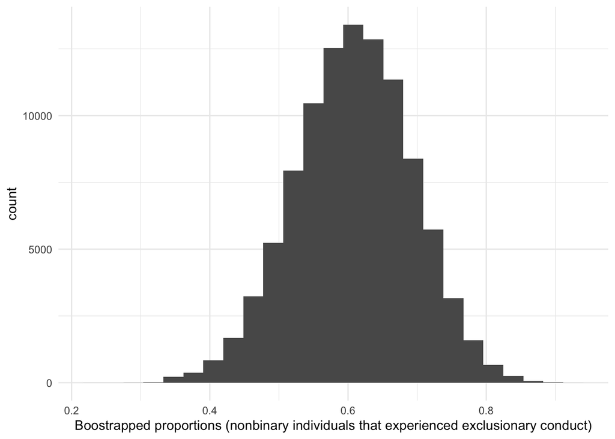

```r
#Histogram of bootsrapped proportions:

## Make a data frame with the vectors of bootstrap sample proportions:
ucsb_resp_100k_df <- data.frame(uscb_resp_prop = ucsb_resp_100k$t)

## Histogram plot:
 ggplot(data = ucsb_resp_100k_df, aes(x = uscb_resp_prop)) +
  geom_histogram(bins = 25) +
   theme_minimal()+
   labs(x = "Boostrapped proportions (nonbinary individuals that experienced exclusionary conduct)")
```

**Figure 1.** Histogram of bootstrap proportions (100,000 bootstrap samples from an original sample n = 36) for nonbinary/genderqueer UCSB community members that had personally experienced “exclusionary, offensive, hostile or intimidating conduct”. Data: UCSB Campus Climate Project Final Report (2014).

```r
#Use bootstrapped sampling distribution to find the confidence interval:

ucsb_resp_100k_ci <- boot.ci(ucsb_resp_100k, conf = 0.95)

#results:
ucsb_resp_100k_ci
```

[output not shown]

The proportion of UCSB community members identifying as nonbinary/genderqueer who responded that they had personally experienced “exclusionary, offensive, hostile or intimidating conduct” is 0.61 (n = 36), with a bootstrapped 95% confidence interval of [0.45, 0.77] (n = 100,000 bootstrap samples). Data: UCSB Campus Climate Project Final Report (2014).